# report

## Introduction

The first dataset, `death`, includes 2012 and 2013 death counts in the state of California by zipcode and gender. It was sourced from data catalog data.gov, and it is available to the public at https://data.world/ellianas/untitledproject-3-19-2024/workspace/project-summary?agentid=health&datasetid=death-by-zip-code-by-gender

The second data set, `income`, includes 2012 and 2013 Incomes fro several states by zipcode. It was sourced from the IRS Statistics of Income, and it is available to the public at https://data.world/jonloyens/irs-income-by-zip-code/workspace/project-summary?agentid=jonloyens&datasetid=irs-income-by-zip-code

The last data set, `city`, includes the city and county name and the population size for all California zipcodes. It was sourced from The World Population Review, and it is available to the public at https://worldpopulationreview.com/zips/california

Below, we import all three datasets.

```python
import pandas as pd

death = pd.read_csv("Death_by_ZIP_Code_by_Gender__2012_-_2013.csv")
income = pd.read_csv("IRSIncomeByZipCode.csv")
city = pd.read_csv("ca-zip-codes-data.csv")
```

## Reprocessing

We merge `death`, `income`, and `city` by *ZIPCODE* into a single dataframe.

```python
merge = pd.merge(death, income, on='ZIPCODE')
city.rename(columns={'zip': 'ZIPCODE'}, inplace=True)
df = pd.merge(merge, city, on='ZIPCODE')
```

We rename that columns in the dataframe so that they are all of the same format, which makes utilizing their names more simple in future steps. Then, we drop all missing values and nonmeaningful rows and columns from the dataframe. We add the column `Percent death count`, so we can see the number of deaths relative to the population. Finally, we reorder the columns of the dataframe to make it more easily read.

```python
df.rename(columns={'YEAR': 'Year', 'ZIPCODE': 'Zipcode', 'GENDER': 'Gender', 'COUNT': 'Death count', 'STATE': 'State', 'population': 'Population', 'city': 'City', 'county': 'County','Number of returns':'Number of tax returns'}, inplace=True)

df.dropna(inplace=True)
df = df[(df['Year'] == 2013) & (df['Gender'] == 'Female')]
df.drop(['Zipcode','Year','Location 1','State','Adjusted gross income (AGI)','Number of returns with total income','Total income amount','Number of returns with taxable income','Taxable income amount','Avg taxable income','City','Gender','Number of tax returns'],axis=1,inplace=True)

df['Percent death count'] = df['Death count'] / df['Population'] * 100

df = df[['County','Population','Death count','Percent death count','Avg AGI','Avg total income']]
```

Here, we change the format of `Avg AGI` and `Avg total income` from its default, scientific notation, to standard notation.

```python
df['Avg AGI'] = df['Avg AGI'] * 1000
df['Avg total income'] = df['Avg total income'] * 1000
```

This is the final dataframe after reprocessing. It contains death, population, and income data for females. This data only contains information from 2013 for the state of California.

```python
df.head()
```

|  | County | Population | Death count | Percent death count | Avg AGI | Avg total income |
| --- | --- | --- | --- | --- | --- | --- |
| 2827 | Los Angeles | 57652 | 102.0 | 0.176924 | 25152.93276 | 25358.70291 |
| 2829 | Los Angeles | 53108 | 109.0 | 0.205242 | 24410.49578 | 24637.55274 |
| 2831 | Los Angeles | 75024 | 134.0 | 0.178610 | 23404.62185 | 23638.19710 |
| 2833 | Los Angeles | 58833 | 118.0 | 0.200568 | 59128.94737 | 60286.22076 |
| 2835 | Los Angeles | 37754 | 79.0 | 0.209249 | 45821.12767 | 46486.71419 |

We want to preform an outlier analysis in order to identify any out of the ordinary observations. The condition for outliers will be based on a 1.5 interquartile range.

```python
import seaborn as sns

def is_outlier(x):
    Q25, Q75 = x.quantile([.25,.75])
    IQR = Q75 - Q25
    return (x < Q25 - 1.5*IQR) |  (x > Q75 + 1.5*IQR)

by_event = df.groupby("County")
outliers = by_event["Death count"].transform(is_outlier)
(df.loc[outliers,"County"].value_counts()).to_frame()
```

| County | count |
| --- | --- |
| Los Angeles | 4 |
| Shasta | 4 |
| Humboldt | 4 |
| Mendocino | 3 |
| Tulare | 3 |
| Siskiyou | 2 |
| El Dorado | 2 |
| Amador | 2 |
| Merced | 2 |
| Orange | 2 |
| Lake | 2 |
| Yuba | 2 |
| Plumas | 1 |
| Nevada | 1 |
| Tehama | 1 |
| Sacramento | 1 |
| Del Norte | 1 |
| Tuolumne | 1 |
| Stanislaus | 1 |
| Mariposa | 1 |
| Santa Cruz | 1 |
| San Benito | 1 |
| Marin | 1 |
| Contra Costa | 1 |
| Napa | 1 |
| Alameda | 1 |
| Inyo | 1 |
| Kings | 1 |
| Lassen | 1 |

```python
by_county_outliers = df.loc[outliers,"County"].value_counts().sum()
print(f"Number of death count outliers by county = {by_county_outliers}")
total_num_deathcount = df['Death count'].shape[0]
print(f"Total number of death count observations = {total_num_deathcount}")
percent_outliers = (by_county_outliers / total_num_deathcount) * 100
print(f"Percent of death count outliers when grouped by county = {percent_outliers:.2f}%")
```

```
Number of death count outliers by county = 49
Total number of death count observations = 1412
Percent of death count outliers when grouped by county = 3.47%
```

Based on the outlier analysis, we can see how many outliers there are for `Death count` in each county in California. We can also conclude. We can also conclude that 3.47% percent of death counts in California are outliers when group by county.

## Summary Data Analysis

The summary statistics for all numerical columns of the dataframe are as follows:

```python
df[['County','Population','Death count','Percent death count','Avg AGI','Avg total income']].describe()
```

|  | Population | Death count | Percent death count | Avg AGI | Avg total income |
| --- | --- | --- | --- | --- | --- |
| count | 1412.000000 | 1412.000000 | 1412.000000 | 1.412000e+03 | 1.412000e+03 |
| mean | 27627.461048 | 84.987252 | 0.368747 | 7.445815e+04 | 7.574361e+04 |
| std | 22090.010399 | 69.191318 | 0.320635 | 7.132591e+04 | 7.237741e+04 |
| min | 33.000000 | 1.000000 | 0.023149 | 2.040964e+04 | 2.060633e+04 |
| 25% | 7298.750000 | 23.000000 | 0.236887 | 4.276960e+04 | 4.350000e+04 |
| 50% | 26031.500000 | 73.500000 | 0.321837 | 5.697303e+04 | 5.801139e+04 |
| 75% | 41666.250000 | 130.000000 | 0.425047 | 7.997999e+04 | 8.138399e+04 |
| max | 106042.000000 | 420.000000 | 9.090909 | 1.149294e+06 | 1.160494e+06 |

The number of observations per county are as follows:

```python
df['County'].value_counts().to_frame()
```

| County | count |
| --- | --- |
| Los Angeles | 272 |
| San Diego | 93 |
| Orange | 84 |
| Riverside | 67 |
| San Bernardino | 66 |
| Santa Clara | 54 |
| Sacramento | 51 |
| Alameda | 47 |
| Fresno | 44 |
| Kern | 39 |
| Contra Costa | 36 |
| San Joaquin | 28 |
| Sonoma | 27 |
| San Francisco | 26 |
| San Mateo | 25 |
| Ventura | 23 |
| Stanislaus | 22 |
| Monterey | 21 |
| Humboldt | 21 |
| Tulare | 20 |
| San Luis Obispo | 19 |
| Shasta | 18 |
| Merced | 17 |
| Placer | 17 |
| Santa Barbara | 17 |
| El Dorado | 16 |
| Mendocino | 15 |
| Marin | 15 |
| Butte | 15 |
| Siskiyou | 15 |
| Santa Cruz | 12 |
| Calaveras | 12 |
| Solano | 11 |
| Yolo | 10 |
| Lake | 10 |
| Imperial | 10 |
| Madera | 10 |
| Yuba | 9 |
| Tuolumne | 8 |
| Nevada | 7 |
| Lassen | 7 |
| Napa | 7 |
| Amador | 7 |
| Sutter | 7 |
| Plumas | 7 |
| Trinity | 6 |
| Kings | 6 |
| Tehama | 5 |
| Inyo | 4 |
| Colusa | 4 |
| Mariposa | 4 |
| San Benito | 4 |
| Del Norte | 4 |
| Glenn | 3 |
| Mono | 3 |
| Modoc | 3 |
| Sierra | 1 |
| Alpine | 1 |

We want to plot the graphical components of every column. We do so by using a pairplot, so we can see multiple pairwise scatter plots all at once.

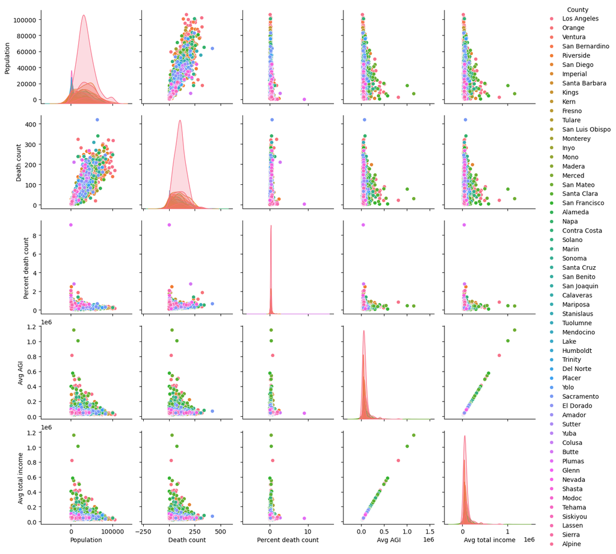

```python
import matplotlib.pyplot as plt
sns.pairplot(data=df, hue='County')
```

To further explore the dataset, we make boxplot plots of `Death count`, `Population`, and `Avg total income` against `County`.

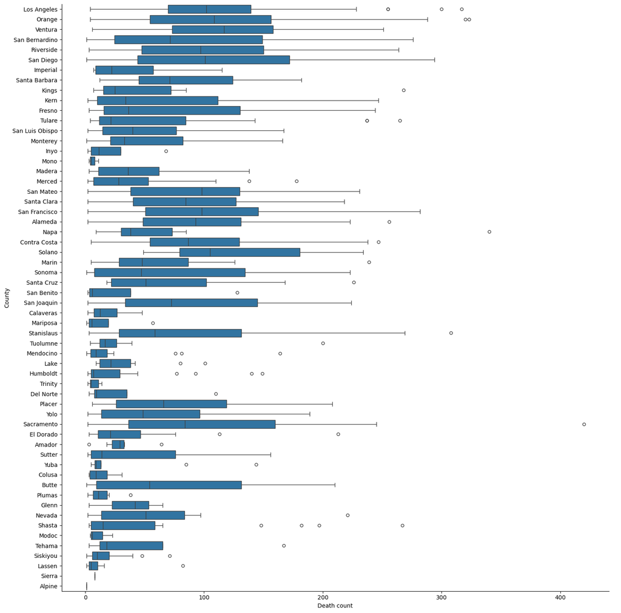

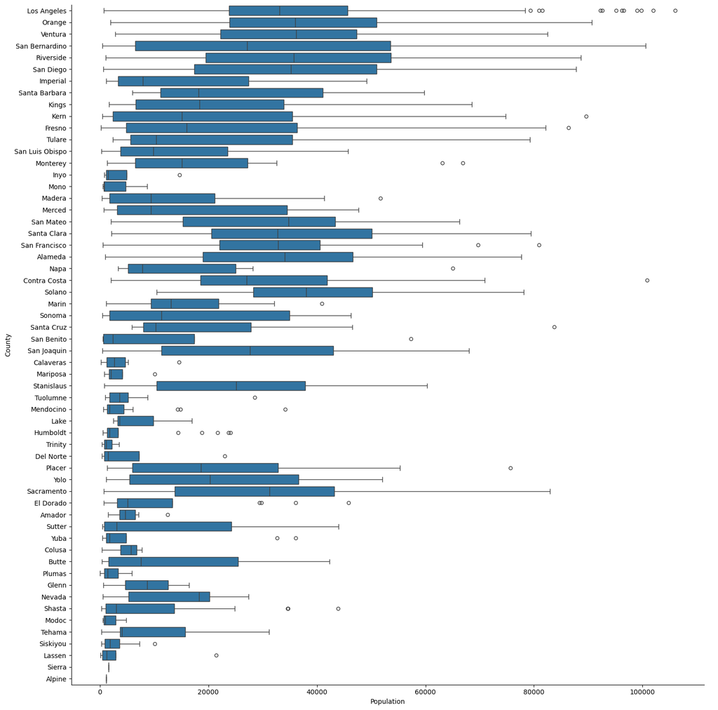

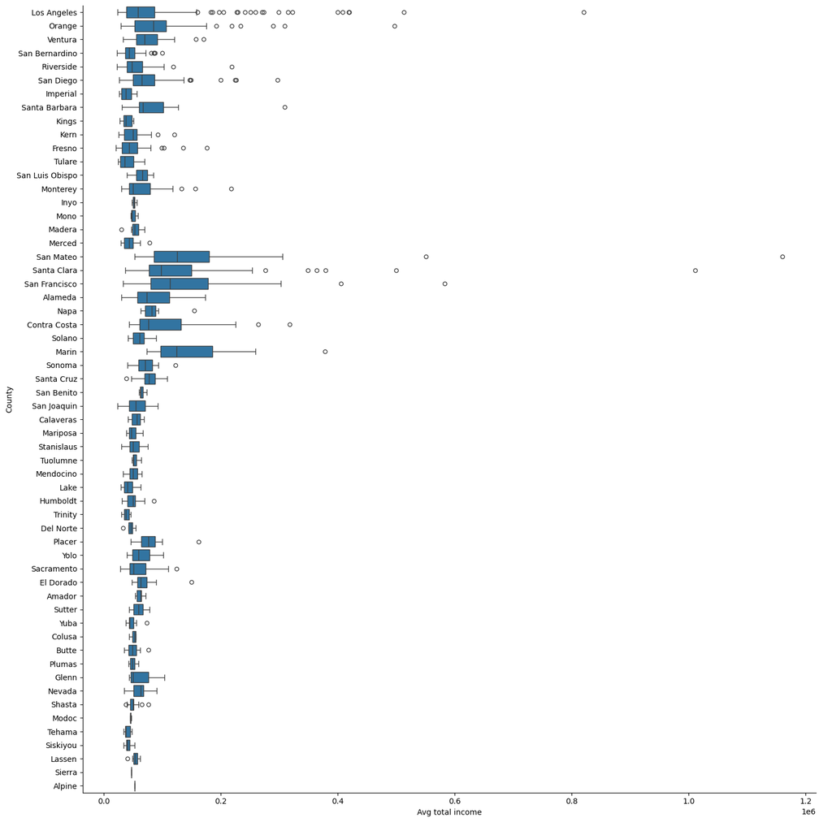

```python
import matplotlib.pyplot as plt

sns.catplot(data=df, x="Death count", y="County", kind="box", height=15)
sns.catplot(data=df, x="Population", y="County", kind="box", height=15)
sns.catplot(data=df, x="Avg total income", y="County", kind="box", height=15)
```

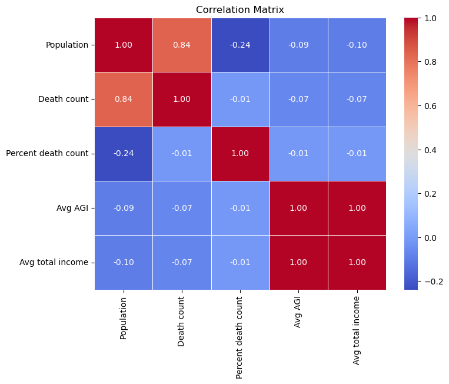

```python
import seaborn as sns
import matplotlib.pyplot as plt

corr_matrix = df[['Population','Death count','Percent death count','Avg AGI','Avg total income']].corr()

plt.figure(figsize=(8, 6))
sns.heatmap(corr_matrix, annot=True, cmap='coolwarm', fmt=".2f", linewidths=0.5)
plt.title('Correlation Matrix')
plt.show()
```

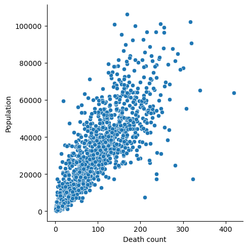

```python
sns.relplot(data=df, x="Death count", y="Population")
```